# 08 — Comparative Risk Analysis (EU vs US)

This notebook synthesises the results of previous modules to compare the risk–return profile of the IBEX 35 and the S&P 500 over the full sample and across market regimes. This notebook tries to figure out how European and US equity markets differ in terms of volatility, drawdowns, tail risk, and contagion over time

The analysis is built on:

- **Realized returns** (level, volatility, drawdowns).
- **Model-implied risk** (EGARCH volatility, VaR/ES backtests).
- **Relative and dynamic measures** (volatility ratios, rolling beta IBEX|SPX, rolling correlation).

The goal is to produce a concise, portfolio-oriented comparison that can be consumed directly in a dashboard Power BI presentation.

### Objectives

- Quantify and compare realised volatility in IBEX vs S&P 500.
- Measure relative risk via volatility ratios and worst drawdowns.
- Analyze time-varying dependence through rolling correlations and beta IBEX|SPX.
- Contrast tail risk using VaR / ES exceedance statistics by region.
- Derive a compact EU vs US risk profile suitable for reporting and asset-allocation discussion.

| File | Description |
| --- | --- |
| `/data/features/returns.csv` | Daily log-returns for IBEX 35 and S&P 500. |
| `/data/results/egarch_volatility.csv` (o equivalente del notebook 04) | EGARCH conditional volatility series for both indices. |
| `/data/results/var_es_results.csv` | VaR/ES coverage and exceedance metrics by model and index. |
| `/data/results/walkforward_errors_summary.csv` | Summary MAE/RMSE by model and index (forecastability comparison). |

### Outputs

[output not shown]

These outputs feed the “EU–US Comparative Risk” section of the Power BI dashboard.

### Tests and Diagnostics

| Test / Metric | Purpose |
| --- | --- |
| Rolling volatility & volatility ratios | Assess which market is structurally more volatile and when the hierarchy switches. |
| Rolling beta IBEX\|SPX | Measure sensitivity of EU equity risk to US market shocks. |
| Rolling correlation | Track contagion / decoupling phases between IBEX and S&P 500. |
| Drawdown analysis | Compare severity and persistence of losses across crises. |
| VaR/ES exceedances by region | Contrast tail risk and model adequacy in EU vs US. |

### Step 1: Setup & Data Loading

This step prepares the working environment and imports all datasets required for the EU–US comparative risk analysis.

```python
# STEP 1 SETUP & DATA LOADING

import pandas as pd
import numpy as np
from pathlib import Path

# 1.0 Define project paths
PROJECT_ROOT  = Path.cwd().parent                 # notebooks/ → root/
DATA_PATH     = PROJECT_ROOT / "data"
FEATURES_PATH = DATA_PATH / "features"
RESULTS_PATH  = DATA_PATH / "results"

# Save in folders
FIGURES_PATH  = PROJECT_ROOT / "figures"
RISK8_DIR = FIGURES_PATH / "08_comparative_risk"
RISK8_DIR.mkdir(parents=True, exist_ok=True)

print("Project paths loaded:")
for p in [DATA_PATH, FEATURES_PATH, RESULTS_PATH, FIGURES_PATH]:
    print(" -", p)

# 1.1 Load returns dataset
print("\nLoading returns dataset...")

returns_file = FEATURES_PATH / "returns.csv"
if not returns_file.exists():
    raise FileNotFoundError(f"Returns file not found: {returns_file}")

returns = pd.read_csv(
    returns_file,
    index_col=0,
    parse_dates=True
)

returns.columns = ["IBEX", "SPX"]

print("Returns columns:", list(returns.columns))
print("IBEX:", returns[['IBEX']].dropna().shape)
print("SPX :", returns[['SPX']].dropna().shape)

# 1.2 Load technical indicators (optional)
ti_file = FEATURES_PATH / "technical_indicators.csv"
if ti_file.exists():
    tech_ind = pd.read_csv(ti_file, index_col=0, parse_dates=True)
    print("\nTechnical indicators loaded:", tech_ind.shape)
else:
    tech_ind = None
    print("\nTechnical indicators not found — continuing without them.")

# 1.3 Load EGARCH volatility (CSV)
egarch_file = RESULTS_PATH / "egarch_volatility.csv"

print("\nLoading EGARCH volatility...")

if egarch_file.exists():
    egarch_vol = pd.read_csv(egarch_file, parse_dates=["Date"])
    egarch_vol = egarch_vol.set_index("Date")
    print("EGARCH volatility loaded:", egarch_vol.shape)
else:
    egarch_vol = None
    print("WARNING: egarch_volatility.csv not found.")

# 1.4 Load DAILY VaR/ES results (REPLACES old var_es_results.csv)
var_es_daily_file = RESULTS_PATH / "var_es_results_daily.csv"

print("\nLoading daily VaR/ES dataset...")

if var_es_daily_file.exists():
    var_es_daily = pd.read_csv(var_es_daily_file, parse_dates=["Date"])
    var_es_daily = var_es_daily.sort_values(["Date", "Index"])
    print("Daily VaR/ES loaded:", var_es_daily.shape)
else:
    var_es_daily = None
    print("WARNING: var_es_results_daily.csv not found — VaR comparisons limited.")

# 1.5 Load walk-forward summary (Notebook 7)
wfsum_file = RESULTS_PATH / "walkforward_errors_summary.csv"

if wfsum_file.exists():
    wf_summary = pd.read_csv(wfsum_file)
    print("\nWalk-forward summary loaded:", wf_summary.shape)
else:
    wf_summary = None
    print("\nWarning: walkforward_errors_summary.csv not found.")

# 1.6 Create aligned return panel (RV needs this)
panel = returns.copy().dropna()
print("\nAligned return panel:", panel.shape)
print(panel.head())

print("\nSetup & data loading completed.")

if "Date" in panel.columns:
    panel = panel.drop(columns=["Date"])

panel.index.name = "Date"
```

```
Project paths loaded:
 - /home/apalo/projects/ibex-sp500-forecasting/data
 - /home/apalo/projects/ibex-sp500-forecasting/data/features
 - /home/apalo/projects/ibex-sp500-forecasting/data/results
 - /home/apalo/projects/ibex-sp500-forecasting/figures

Loading returns dataset...
Returns columns: ['IBEX', 'SPX']
IBEX: (6421, 1)
SPX : (6421, 1)

Technical indicators loaded: (6738, 8)

Loading EGARCH volatility...
EGARCH volatility loaded: (6421, 2)

Loading daily VaR/ES dataset...
Daily VaR/ES loaded: (12842, 7)

Walk-forward summary loaded: (4, 11)

Aligned return panel: (6421, 2)
                IBEX       SPX
Date
2000-01-04 -0.035364 -0.039099
2000-01-05 -0.031131  0.001920
2000-01-07  0.021790  0.027685
2000-01-10  0.006366  0.011128
2000-01-11 -0.014505 -0.013149

Setup & data loading completed.
```

### Step 2: Rolling Volatility Comparison

This step quantifies and compares the time-varying volatility of the IBEX 35 and the S&P 500. The aim is that both measures (realised and model-implied) are aligned on the same date index and merged into a single panel, so we can later produce two sets of plots in order to make a comparision easily. That establishes the first layer of the EU–US risk comparison by showing how market volatility evolves over time, which market is structurally more volatile, and how realised volatility contrasts with model-implied EGARCH estimates.

```
EGARCH volatility loaded successfully.
Computing realized volatility (20-day rolling window)...
Realized volatility computed: (6402, 2)
Aligning EGARCH volatility with return panel...
EGARCH volatility merged with realized volatility.
```

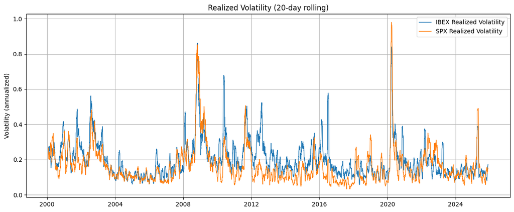

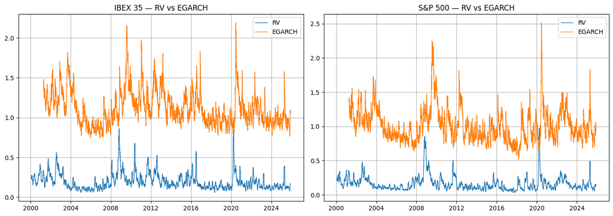

```
Step 2 completed.
```

```python
# STEP 2 — ROLLING VOLATILITY COMPARISON

import pandas as pd
import numpy as np
import matplotlib.pyplot as plt
from pathlib import Path

# 2.0 Load EGARCH volatility (if available)

RESULTS_PATH = Path.cwd().parent / "data" / "results"

try:
    egarch_vol = pd.read_csv(RESULTS_PATH / "egarch_volatility.csv", parse_dates=["Date"])
    egarch_vol = egarch_vol.set_index("Date")
    print("EGARCH volatility loaded successfully.")
except FileNotFoundError:
    egarch_vol = None
    print("EGARCH volatility file not found. Continuing with realized volatility only.")

# 2.1 Compute realized volatility (20-day rolling window)

print("Computing realized volatility (20-day rolling window)...")

rv = panel.rolling(window=20).std() * np.sqrt(252)
rv.columns = ["IBEX_RV", "SPX_RV"]

print("Realized volatility computed:", rv.dropna().shape)

# 2.2 Merge EGARCH volatility (if available)

if egarch_vol is not None:
    print("Aligning EGARCH volatility with return panel...")
    egarch_aligned = egarch_vol.reindex(rv.index)

    rv["IBEX_EGARCH"] = egarch_aligned["Vol_IBEX"]
    rv["SPX_EGARCH"]  = egarch_aligned["Vol_SPX"]

    print("EGARCH volatility merged with realized volatility.")
else:
    print("EGARCH volatility unavailable. Proceeding with realized volatility only.")

# 2.3 Plot realized volatility

plt.figure(figsize=(12, 5))
plt.plot(rv["IBEX_RV"], label="IBEX Realized Volatility", linewidth=1)
plt.plot(rv["SPX_RV"], label="SPX Realized Volatility", linewidth=1)
plt.title("Realized Volatility (20-day rolling)")
plt.ylabel("Volatility (annualized)")
plt.legend()
plt.grid(True)
plt.tight_layout()

# Save figure correctly
plt.gcf().savefig(RISK8_DIR / "01_realized_volatility.png", dpi=300, bbox_inches="tight")

plt.show()

# 2.4 Plot RV vs EGARCH only if EGARCH exists

if egarch_vol is not None:
    fig, axes = plt.subplots(1, 2, figsize=(14, 5))

    axes[0].plot(rv["IBEX_RV"], label="RV", linewidth=1)
    axes[0].plot(rv["IBEX_EGARCH"], label="EGARCH", linewidth=1)
    axes[0].set_title("IBEX 35 — RV vs EGARCH")
    axes[0].legend()
    axes[0].grid(True)

    axes[1].plot(rv["SPX_RV"], label="RV", linewidth=1)
    axes[1].plot(rv["SPX_EGARCH"], label="EGARCH", linewidth=1)
    axes[1].set_title("S&P 500 — RV vs EGARCH")
    axes[1].legend()
    axes[1].grid(True)

    plt.tight_layout()

    fig.savefig(RISK8_DIR / "02_rv_vs_egarch.png", dpi=300, bbox_inches="tight")

    plt.show()

print("Step 2 completed.")
```

### Step 3: Relative Volatility & Drawdowns

In this step, the notebook evaluates how the risk of the IBEX 35 compares to that of the S&P 500 over time. The ratios used show when the European market is more volatile than the U.S. market, and how this relationship shifts across different periods. Also, the cumulative returns are constructed for each index, which allows the calculation of drawdowns. This quantifies the depth and duration of losses each market has suffered historically. Finally, comparative drawdown plots are generated to visually assess which index experiences more severe and persistent declines.

```
Building analysis panel with returns and volatility...
EGARCH volatility added to analysis panel.
Analysis panel shape: (6421, 6)

Computing volatility ratios (IBEX vs SPX)...
Volatility ratio (RV) summary:
count    6402.000000
mean        1.354168
std         0.568461
min         0.421390
25%         0.995439
50%         1.229138
75%         1.594438
max         5.516339
Name: vol_ratio_RV, dtype: float64

Plotting realized volatility ratios...
```

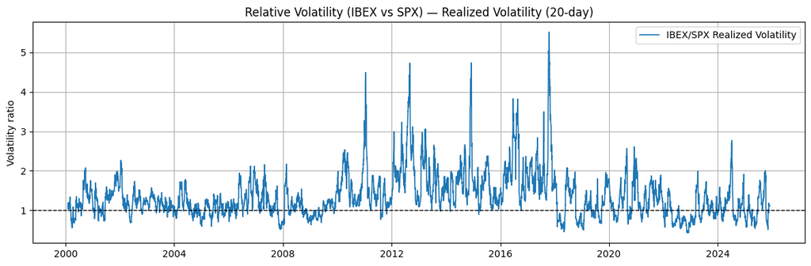

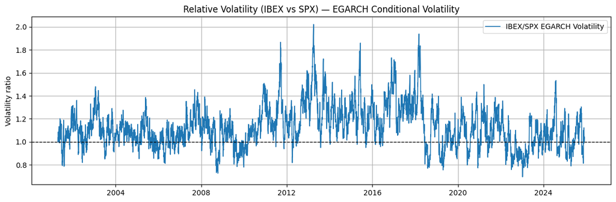

```
Computing cumulative returns and drawdowns...
Max drawdown IBEX: -0.7391063299701268
Max drawdown SPX : -0.6431376778237451

Plotting comparative drawdowns...
```

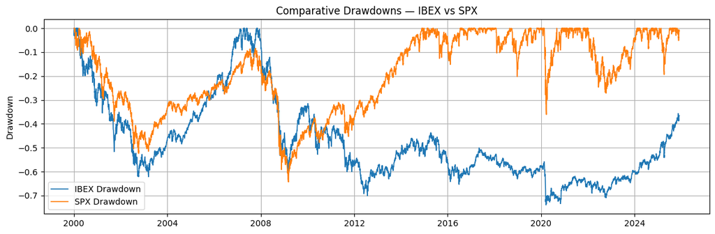

```
Step 3 completed.
```

```python
# STEP 3 — RELATIVE VOLATILITY & DRAWDOWNS

import pandas as pd
import numpy as np
import matplotlib.pyplot as plt

# 3.1 Build analysis panel: returns + realized volatility
print("Building analysis panel with returns and volatility...")

#Starting panel
analysis_panel = panel.join(rv, how="left")

# incorporating egarch if exists
if egarch_vol is not None:
    egarch_aligned = egarch_vol.reindex(analysis_panel.index)
    analysis_panel["IBEX_EGARCH"] = egarch_aligned["Vol_IBEX"]
    analysis_panel["SPX_EGARCH"]  = egarch_aligned["Vol_SPX"]
    print("EGARCH volatility added to analysis panel.")
else:
    print("EGARCH volatility not available.")

print("Analysis panel shape:", analysis_panel.shape)

# 3.2 Volatility ratios (IBEX vs SPX)
print("\nComputing volatility ratios (IBEX vs SPX)...")

analysis_panel["vol_ratio_RV"] = (
    analysis_panel["IBEX_RV"] / analysis_panel["SPX_RV"]
)

if "IBEX_EGARCH" in analysis_panel.columns and "SPX_EGARCH" in analysis_panel.columns:
    analysis_panel["vol_ratio_EGARCH"] = (
        analysis_panel["IBEX_EGARCH"] / analysis_panel["SPX_EGARCH"]
    )
else:
    print("EGARCH volatility ratio unavailable.")

print("Volatility ratio (RV) summary:")
print(analysis_panel["vol_ratio_RV"].dropna().describe())

# 3.3 Plot volatility ratios over time
print("\nPlotting realized volatility ratios...")

fig, ax = plt.subplots(figsize=(12, 4))
ax.plot(analysis_panel.index, analysis_panel["vol_ratio_RV"],
        label="IBEX/SPX Realized Volatility", linewidth=1.2)

ax.axhline(1.0, color="black", linestyle="--", linewidth=1)

ax.set_title("Relative Volatility (IBEX vs SPX) — Realized Volatility (20-day)")
ax.set_ylabel("Volatility ratio")
ax.grid(True)
ax.legend()
plt.tight_layout()
fig.savefig(RISK8_DIR / "03_volatility_ratio_RV.png", dpi=300, bbox_inches="tight")
plt.show()

# Plot EGARCH ratio if exists
if "vol_ratio_EGARCH" in analysis_panel.columns:
    fig, ax = plt.subplots(figsize=(12, 4))
    ax.plot(analysis_panel.index, analysis_panel["vol_ratio_EGARCH"],
            label="IBEX/SPX EGARCH Volatility", linewidth=1.2)
    ax.axhline(1.0, color="black", linestyle="--", linewidth=1)
    ax.set_title("Relative Volatility (IBEX vs SPX) — EGARCH Conditional Volatility")
    ax.set_ylabel("Volatility ratio")
    ax.grid(True)
    ax.legend()
    plt.tight_layout()
    # SAVE FIGURE 2
    fig.savefig(RISK8_DIR / "04_volatility_ratio_EGARCH.png", dpi=300, bbox_inches="tight")
    plt.show()

# 3.4 Cumulative returns and drawdowns (CORREGIDO)
print("\nComputing cumulative returns and drawdowns...")

# Tus retornos se llaman: "IBEX" y "SPX"
rets = analysis_panel[["IBEX", "SPX"]].dropna()

wealth_ibex = (1 + rets["IBEX"]).cumprod()
wealth_spx  = (1 + rets["SPX"]).cumprod()

dd_ibex = wealth_ibex / wealth_ibex.cummax() - 1
dd_spx  = wealth_spx / wealth_spx.cummax() - 1

analysis_panel["DD_IBEX"] = dd_ibex
analysis_panel["DD_SPX"]  = dd_spx

print("Max drawdown IBEX:", dd_ibex.min())
print("Max drawdown SPX :", dd_spx.min())

# 3.5 Plot comparative drawdowns
print("\nPlotting comparative drawdowns...")

fig, ax = plt.subplots(figsize=(12, 4))
ax.plot(dd_ibex.index, dd_ibex, label="IBEX Drawdown", linewidth=1.2)
ax.plot(dd_spx.index, dd_spx, label="SPX Drawdown", linewidth=1.2)

ax.set_title("Comparative Drawdowns — IBEX vs SPX")
ax.set_ylabel("Drawdown")
ax.grid(True)
ax.legend()

plt.tight_layout()

# Save
fig.savefig(RISK8_DIR / "05_volatility_ratio_RV.png", dpi=300, bbox_inches="tight")

plt.show()

print("\nStep 3 completed.")
```

### Step 4: Rolling Beta & Correlation

This step measures how the relationship between the IBEX 35 and the S&P 500 evolves over time, focusing on two key dependence metrics: rolling correlation and rolling beta. First, a clean return panel is prepared using daily IBEX and SPX returns. A 60-day rolling correlation is then computed to capture periods of contagion, decoupling, and structural shifts in cross-market co-movement.

Next, a 120-day rolling beta of the IBEX with respect to the SPX is calculated. This shows how sensitive European equity risk is to U.S. market movements, and whether that sensitivity strengthens or weakens across different regimes. Both series are plotted to visually track changes in dependence, and the resulting metrics are merged back into the main analysis panel for use in later steps.

```
Preparing return panel for rolling correlation & beta...
Return panel shape: (6421, 2)

Computing rolling correlation (IBEX vs SPX)...
Rolling correlation computed: (6362,)
```

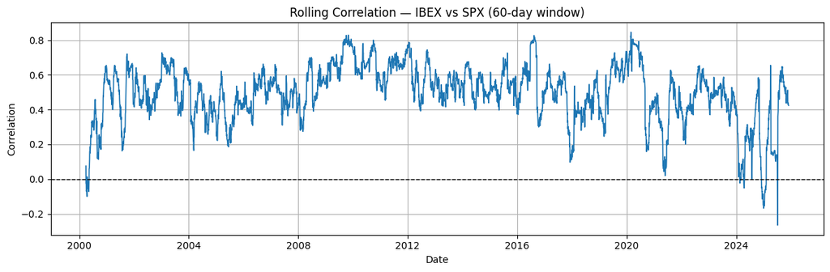

```
Computing rolling beta (IBEX | SPX)...
Rolling beta computed: (6301,)
```

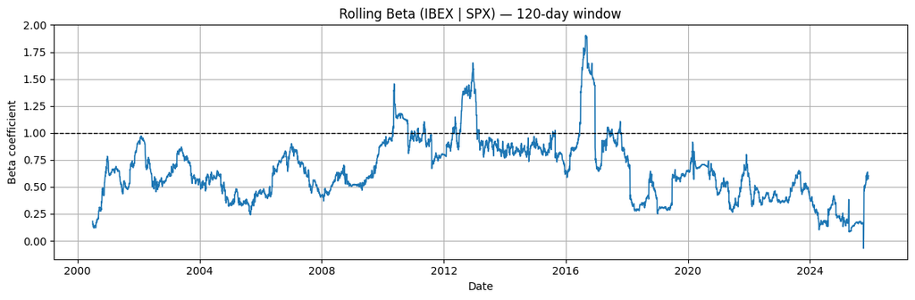

```
Step 4 completed.
Variables added to analysis_panel: rolling_corr, rolling_beta.
```

```python
# STEP 4 — ROLLING BETA & CORRELATION

import pandas as pd
import numpy as np
import matplotlib.pyplot as plt

# 4.1 Prepare return panel (IBEX, SPX)
print("Preparing return panel for rolling correlation & beta...")

# Tus retornos reales se llaman IBEX y SPX (no IBEX_ret / SPX_ret)
ret_panel = analysis_panel[["IBEX", "SPX"]].dropna()

print("Return panel shape:", ret_panel.shape)

# 4.2 Rolling correlation (IBEX ↔ SPX)
print("\nComputing rolling correlation (IBEX vs SPX)...")

window_corr = 60    # ~3 meses

ret_panel["rolling_corr"] = (
    ret_panel["IBEX"].rolling(window_corr).corr(ret_panel["SPX"])
)

print("Rolling correlation computed:", ret_panel["rolling_corr"].dropna().shape)

# Plot rolling correlation
fig, ax = plt.subplots(figsize=(12, 4))
ax.plot(ret_panel.index, ret_panel["rolling_corr"], linewidth=1.2)
ax.axhline(0, color="black", linestyle="--", linewidth=1)

ax.set_title("Rolling Correlation — IBEX vs SPX (60-day window)")
ax.set_ylabel("Correlation")
ax.set_xlabel("Date")
ax.grid(True)

plt.tight_layout()

# SAVE FIGURE 1
fig.savefig(RISK8_DIR / "06_rolling_correlation.png", dpi=300, bbox_inches="tight")

plt.show()

# 4.3 Rolling Beta (IBEX | SPX)
print("\nComputing rolling beta (IBEX | SPX)...")

window_beta = 120    # ~6 meses

def compute_beta(y, x):
    """
    Computes beta = Cov(y,x) / Var(x).
    y = IBEX, x = SPX
    """
    cov = np.cov(y, x, ddof=1)[0, 1]
    var = np.var(x, ddof=1)
    return cov / var if var != 0 else np.nan

betas = []
idx = ret_panel.index

for i in range(window_beta, len(ret_panel)):
    y = ret_panel["IBEX"].iloc[i - window_beta:i]
    x = ret_panel["SPX"].iloc[i - window_beta:i]
    betas.append(compute_beta(y.values, x.values))

beta_series = pd.Series(betas, index=idx[window_beta:])
ret_panel["rolling_beta"] = beta_series

print("Rolling beta computed:", ret_panel["rolling_beta"].dropna().shape)

# 4.4 Plot rolling beta
fig, ax = plt.subplots(figsize=(12, 4))
ax.plot(ret_panel.index, ret_panel["rolling_beta"], linewidth=1.2)
ax.axhline(1.0, color="black", linestyle="--", linewidth=1)

ax.set_title("Rolling Beta (IBEX | SPX) — 120-day window")
ax.set_ylabel("Beta coefficient")
ax.set_xlabel("Date")
ax.grid(True)

plt.tight_layout()
#Save figure
fig.savefig(RISK8_DIR / "07_rolling_beta.png", dpi=300, bbox_inches="tight")

plt.show()

# 4.5 Merge results back into analysis panel
analysis_panel.loc[ret_panel.index, "rolling_corr"] = ret_panel["rolling_corr"]
analysis_panel.loc[ret_panel.index, "rolling_beta"] = ret_panel["rolling_beta"]

print("\nStep 4 completed.")
print("Variables added to analysis_panel: rolling_corr, rolling_beta.")
```

### Step 5: Tail Risk Comparison (VaR / ES)

This step evaluates and compares the tail-risk behavior of the IBEX 35 and the S&P 500 using daily VaR and ES estimates. The VaR/ES results are first loaded and aligned with the original return series. Once aligned, the notebook computes VaR95 and VaR99 exceedances for each index by checking how often daily returns fall below the corresponding VaR thresholds. Exceedance severity—how far returns fall beyond the VaR cutoff—is also calculated to assess the magnitude of tail events.

A summary table reports the exceedance rates and average severity for both markets. The notebook then visualizes the rolling exceedance frequency (200-day window), showing periods where either index experiences unusually high tail risk. A professional scatter plot of exceedance severity highlights the intensity and timing of extreme losses.

These metrics and plots provide a direct comparison of EU vs US tail risk, indicating which market experiences more frequent and more severe violations of risk forecasts, and how this evolves across market regimes.

```
Starting Tail Risk Comparison (VaR/ES)...
Daily VaR/ES dataset loaded: (12842, 7)
Returns aligned: (6421, 2)
Merged panel: (6421, 6)

Tail Risk Summary:
  Index  Exc_rate_95  Exc_rate_99  Avg_sev_95
0  IBEX     0.052484     0.012459   -0.957025
1   SPX     0.037533     0.006853   -0.920789
```

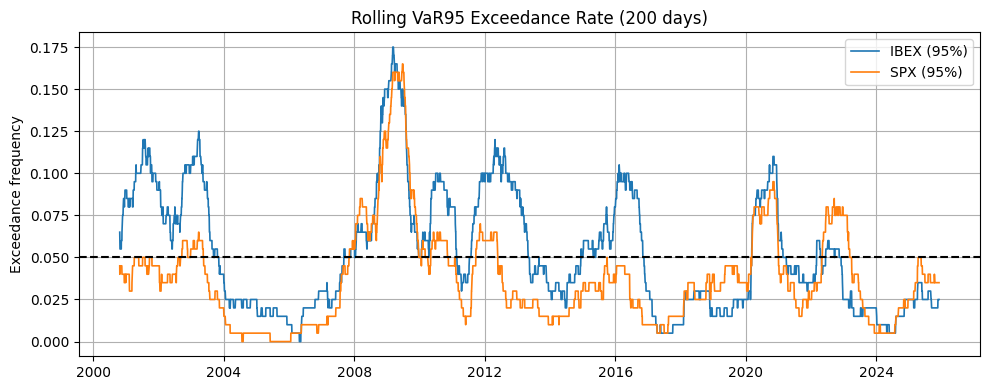

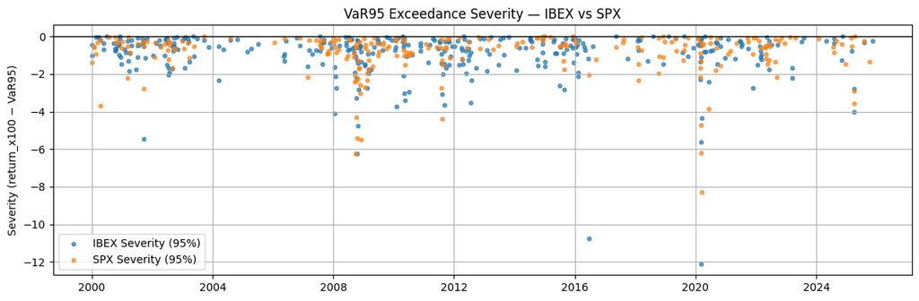

```
Step 5 completed (clean version).
```

```python
# STEP 5 — TAIL RISK COMPARISON (VaR / ES) — CLEAN VERSION

import pandas as pd
import numpy as np
import matplotlib.pyplot as plt

print("Starting Tail Risk Comparison (VaR/ES)...")

# 5.1 Load DAILY VaR/ES results
var_es_file = RESULTS_PATH / "var_es_results_daily.csv"

if var_es_file.exists():
    var_es = pd.read_csv(var_es_file, parse_dates=["Date"])
    var_es = var_es.sort_values(["Date", "Index"])
    print("Daily VaR/ES dataset loaded:", var_es.shape)
else:
    print("WARNING: var_es_results_daily.csv NOT FOUND.")
    var_es = None

# 5.2 Prepare returns (from original returns DF)
#      returns: columnas ["IBEX", "SPX"] en DECIMALES
rets = returns[["IBEX", "SPX"]].dropna()
rets.columns = ["IBEX_ret", "SPX_ret"]
print("Returns aligned:", rets.shape)

# 5.3 Compute exceedances for VaR95 / VaR99
if var_es is not None:
    # Pivot diario: VaR95_IBEX, VaR95_SPX, ...
    var_pivot = var_es.pivot(index="Date", columns="Index",
                             values=["VaR95", "VaR99"])
    var_pivot.columns = ["_".join(col) for col in var_pivot.columns]

    # Alinear fechas de VaR con las de los retornos
    var_pivot = var_pivot.reindex(rets.index)

    aligned = rets.join(var_pivot, how="inner")
    print("Merged panel:", aligned.shape)

    # VaR está en %, retornos en decimales → pasamos retornos a %
    aligned["IBEX_ret_pct"] = 100 * aligned["IBEX_ret"]
    aligned["SPX_ret_pct"]  = 100 * aligned["SPX_ret"]

    # Exceedances 95 / 99
    aligned["IBEX_exc_95"] = (aligned["IBEX_ret_pct"] < aligned["VaR95_IBEX"]).astype(int)
    aligned["SPX_exc_95"]  = (aligned["SPX_ret_pct"]  < aligned["VaR95_SPX"]).astype(int)

    aligned["IBEX_exc_99"] = (aligned["IBEX_ret_pct"] < aligned["VaR99_IBEX"]).astype(int)
    aligned["SPX_exc_99"]  = (aligned["SPX_ret_pct"]  < aligned["VaR99_SPX"]).astype(int)

    # Severity (también en %)
    aligned["IBEX_sev_95"] = np.where(
        aligned["IBEX_exc_95"] == 1,
        aligned["IBEX_ret_pct"] - aligned["VaR95_IBEX"],
        np.nan
    )
    aligned["SPX_sev_95"] = np.where(
        aligned["SPX_exc_95"] == 1,
        aligned["SPX_ret_pct"] - aligned["VaR95_SPX"],
        np.nan
    )

else:
    aligned = rets.copy()
    print("Skipping VaR/ES calculations.")

# 5.4 Summary table
if var_es is not None:
    summary = pd.DataFrame({
        "Index": ["IBEX", "SPX"],
        "Exc_rate_95": [aligned["IBEX_exc_95"].mean(), aligned["SPX_exc_95"].mean()],
        "Exc_rate_99": [aligned["IBEX_exc_99"].mean(), aligned["SPX_exc_99"].mean()],
        "Avg_sev_95":  [aligned["IBEX_sev_95"].mean(), aligned["SPX_sev_95"].mean()]
    })
    print("\nTail Risk Summary:")
    print(summary)

# 5.5 Rolling Exceedance Rate (VaR95)
if var_es is not None:
    fig, ax = plt.subplots(figsize=(10, 4))
    ax.plot(aligned["IBEX_exc_95"].rolling(200).mean(), label="IBEX (95%)", linewidth=1.2)
    ax.plot(aligned["SPX_exc_95"].rolling(200).mean(), label="SPX (95%)", linewidth=1.2)

    ax.axhline(0.05, color="black", linestyle="--")
    ax.set_title("Rolling VaR95 Exceedance Rate (200 days)")
    ax.set_ylabel("Exceedance frequency")
    ax.grid(True)
    ax.legend()
    plt.tight_layout()
    #save figure
    fig.savefig(RISK8_DIR / "08_exceedance_rate_95.png", dpi=300, bbox_inches="tight")
    plt.show()

# 5.6 Scatter Plot — VaR95 Exceedance Severity
if var_es is not None:

    fig, ax = plt.subplots(figsize=(12, 4))

    ax.scatter(
        aligned.index,
        aligned["IBEX_sev_95"],
        s=12,
        alpha=0.7,
        label="IBEX Severity (95%)"
    )

    ax.scatter(
        aligned.index,
        aligned["SPX_sev_95"],
        s=12,
        alpha=0.7,
        label="SPX Severity (95%)"
    )

    ax.axhline(0, color="black", linewidth=1)
    ax.set_title("VaR95 Exceedance Severity — IBEX vs SPX")
    ax.set_ylabel("Severity (return_x100 − VaR95)")
    ax.grid(True)
    ax.legend()
    plt.tight_layout()

#Save figure
    fig.savefig(RISK8_DIR / "09_exceedance_severity_95.png", dpi=300, bbox_inches="tight")
    plt.show()


# 5.7 Add variables to analysis_panel
if var_es is not None:
    for col in [
        "IBEX_exc_95", "SPX_exc_95",
        "IBEX_exc_99", "SPX_exc_99",
        "IBEX_sev_95", "SPX_sev_95"
    ]:
        analysis_panel[col] = aligned[col]

print("\nStep 5 completed (clean version).")
```

### Step 6: Visual Summary

This step consolidates the entire EU–US risk comparison into a set of key charts that summarize the main insights from the notebook. Instead of introducing new calculations, Step 6 focuses on presenting the essential diagnostics in a clean and interpretable way, allowing you (or a reader of the TFM/Power BI dashboard) to grasp the relative behaviour of IBEX vs SPX at a glance.

The volatility plots highlight how realized and EGARCH-implied risk evolve across time for both markets, revealing periods where one region becomes structurally more volatile than the other. The rolling correlation chart shows how tightly linked European and U.S. equity returns are, identifying episodes of contagion or temporary decoupling. Rolling beta provides a complementary view by measuring how sensitive IBEX returns are to S&P 500 shocks—an essential indicator of cross-market dependence.

The VaR severity scatter visualizes the magnitude of tail-risk violations, showing whether extreme losses are more abrupt in Europe or the U.S. Finally, the comparative drawdown plot captures the depth and persistence of market declines, helping assess which index suffers more severe downturns during crisis periods.

Together, these visuals form the executive summary of the entire analysis: they condense volatility, dependence, tail risk, and drawdowns into a compact picture of EU–US risk dynamics.

```
Starting visual summary...
```

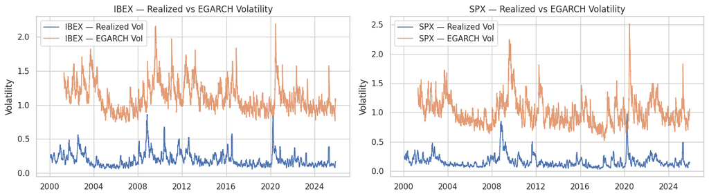

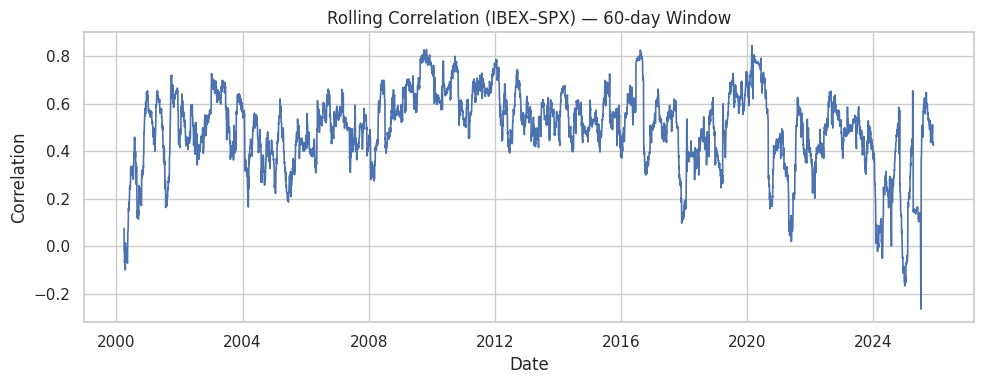

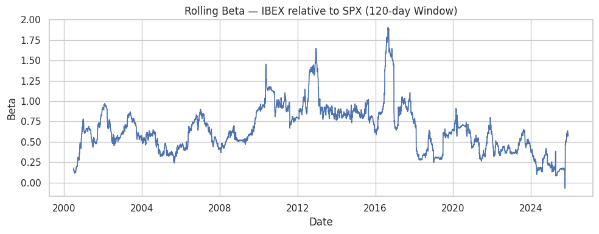

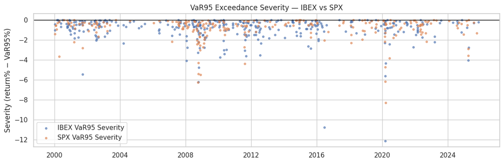

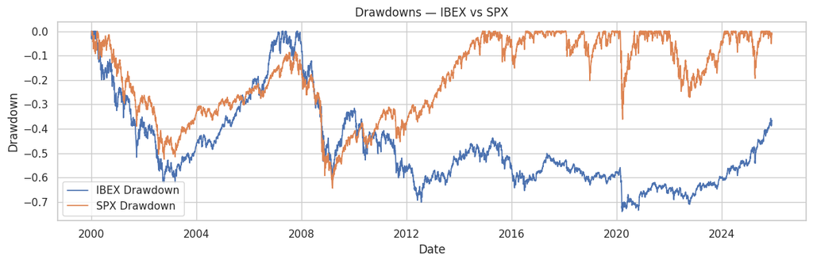

```
Step 6 completed.
```

```python
# STEP 6 VISUAL SUMMARY (KEY PLOTS)

import matplotlib.pyplot as plt
import seaborn as sns

sns.set_theme(style="whitegrid")

print("Starting visual summary...")

# 6.1 Realized vs EGARCH Volatility
fig, ax = plt.subplots(1, 2, figsize=(14, 4))

ax[0].plot(rv.index, rv["IBEX_RV"], label="IBEX — Realized Vol", linewidth=1.2)
if "IBEX_EGARCH" in rv.columns:
    ax[0].plot(rv.index, rv["IBEX_EGARCH"], label="IBEX — EGARCH Vol", linewidth=1.2, alpha=0.8)
ax[0].set_title("IBEX — Realized vs EGARCH Volatility")
ax[0].set_ylabel("Volatility")
ax[0].grid(True)
ax[0].legend()

ax[1].plot(rv.index, rv["SPX_RV"], label="SPX — Realized Vol", linewidth=1.2)
if "SPX_EGARCH" in rv.columns:
    ax[1].plot(rv.index, rv["SPX_EGARCH"], label="SPX — EGARCH Vol", linewidth=1.2, alpha=0.8)
ax[1].set_title("SPX — Realized vs EGARCH Volatility")
ax[1].set_ylabel("Volatility")
ax[1].grid(True)
ax[1].legend()

plt.tight_layout()
fig.savefig(RISK8_DIR / "10_realized_vs_egarch_volatility.png", dpi=300, bbox_inches="tight")
plt.show()

# 6.2 Rolling Correlation (IBEX–SPX)
plt.figure(figsize=(10, 4))
plt.plot(ret_panel.index, ret_panel["rolling_corr"], linewidth=1.2)
plt.title("Rolling Correlation (IBEX–SPX) — 60-day Window")
plt.xlabel("Date")
plt.ylabel("Correlation")
plt.grid(True)
plt.tight_layout()
plt.savefig(RISK8_DIR / "11_rolling_correlation_summary.png", dpi=300, bbox_inches="tight")
plt.show()

# 6.3 Rolling Beta (IBEX | SPX)
plt.figure(figsize=(10, 4))
plt.plot(ret_panel.index, ret_panel["rolling_beta"], linewidth=1.2)
plt.title("Rolling Beta — IBEX relative to SPX (120-day Window)")
plt.xlabel("Date")
plt.ylabel("Beta")
plt.grid(True)
plt.tight_layout()
plt.savefig(RISK8_DIR / "12_rolling_beta_summary.png", dpi=300, bbox_inches="tight")
plt.show()

# 6.4 Tail Risk — VaR95 Severity (scatter, best practice)
if "IBEX_sev_95" in analysis_panel.columns:

    fig, ax = plt.subplots(figsize=(12, 4))

    ax.scatter(
        analysis_panel.index,
        analysis_panel["IBEX_sev_95"],
        s=10, alpha=0.6,
        label="IBEX VaR95 Severity"
    )

    ax.scatter(
        analysis_panel.index,
        analysis_panel["SPX_sev_95"],
        s=10, alpha=0.6,
        label="SPX VaR95 Severity"
    )

    ax.axhline(0, color="black", linewidth=1)
    ax.set_title("VaR95 Exceedance Severity — IBEX vs SPX")
    ax.set_ylabel("Severity (return% − VaR95%)")
    ax.grid(True)
    ax.legend()
    plt.tight_layout()
    fig.savefig(RISK8_DIR / "13_exceedance_severity_summary.png", dpi=300, bbox_inches="tight")
    plt.show()
else:
    print("Tail-risk severity not available in analysis_panel — skipping scatter plot.")

# 6.5 Drawdowns — IBEX vs SPX
plt.figure(figsize=(12, 4))
plt.plot(analysis_panel.index, analysis_panel["DD_IBEX"], label="IBEX Drawdown", linewidth=1.2)
plt.plot(analysis_panel.index, analysis_panel["DD_SPX"],  label="SPX Drawdown",  linewidth=1.2)

plt.title("Drawdowns — IBEX vs SPX")
plt.ylabel("Drawdown")
plt.xlabel("Date")
plt.grid(True)
plt.legend()
plt.tight_layout()
plt.savefig(RISK8_DIR / "14_drawdowns_summary.png", dpi=300, bbox_inches="tight")
plt.show()

print("Step 6 completed.")
```

### Step 7: Analytical Summary (Economic Interpretation)

The drawdown analysis reinforces this structural vulnerability. Although both markets suffer severe losses during global crises, **European drawdowns tend to be deeper and more persistent**. The maximum historical drawdown of the IBEX is significantly worse than that of the S&P 500, and the recovery process is slower, less consistent, and more volatile. This suggests that long-term investors in European equities face a higher probability of prolonged underwater periods and more severe capital impairment during downturns, especially when compared to the more robust recovery tendencies of the U.S. market.

Overall, the analysis converges on a single conclusion:

The U.S. equity market offers a more stable, predictable, and resilient risk environment, while the European market presents a higher, more reactive, and more fragile risk profile.

For asset-allocation purposes, this implies that European equity exposure should be treated as a higher-risk satellite position, managed with tighter controls, smaller weights, or hedging overlays, particularly during periods of global instability. In contrast, U.S. exposures function more naturally as a core allocation, supported by deeper liquidity, stronger sectoral diversification, smoother recovery patterns, and a more consistent tail-risk structure.

```python
# STEP 8 — EXPORT RESULTS FOR POWER BI

import sys
from pathlib import Path
import pandas as pd

print("Starting Step 8 — Exporting results to Power BI...")

# 8.0 PATH SETUP AND export() FUNCTION

PROJECT_ROOT = Path.cwd().parent
SRC_DIR = PROJECT_ROOT / "src"

# Add project paths to sys.path (Linux + Windows compatibility)
if str(PROJECT_ROOT) not in sys.path:
    sys.path.append(str(PROJECT_ROOT))
if str(SRC_DIR) not in sys.path:
    sys.path.append(str(SRC_DIR))

# Custom export function (exports also to Windows Desktop)
from src.export import export

# EXPORT PATH for secondary datasets
RESULTS_PATH = PROJECT_ROOT / "data" / "results"
RESULTS_PATH.mkdir(parents=True, exist_ok=True)

print("Results export path:", RESULTS_PATH)

# 8.1 FIX DATE COLUMN

analysis_panel = analysis_panel.copy()

date_cols = [c for c in analysis_panel.columns if c.lower().startswith("date")]

if len(date_cols) == 0:
    analysis_panel.insert(0, "Date", analysis_panel.index)
else:
    best = None
    best_valid = -1
    for col in date_cols:
        valid = pd.to_datetime(analysis_panel[col], errors="coerce").notna().sum()
        if valid > best_valid:
            best_valid = valid
            best = col

    analysis_panel["Date"] = pd.to_datetime(analysis_panel[best], errors="coerce")

    for col in date_cols:
        if col != "Date" and col != best:
            del analysis_panel[col]

cols = ["Date"] + [c for c in analysis_panel.columns if c != "Date"]
analysis_panel = analysis_panel[cols]

print("Final Date column dtype:", analysis_panel["Date"].dtype)
print("Columns now:", analysis_panel.columns.tolist())

# 8.2 SUMMARY TABLE

summary_data = {
    "Metric": [
        "Mean_Return",
        "Volatility_RV",
        "Volatility_EGARCH",
        "Max_Drawdown",
        "VaR95_Exceedance_Rate",
        "VaR99_Exceedance_Rate",
        "Avg_VaR95_Severity",
        "Beta_Mean",
        "Beta_Min",
        "Beta_Max",
        "Corr_Mean"
    ],

    "IBEX": [
        analysis_panel["IBEX"].mean(),
        analysis_panel["IBEX_RV"].mean(),
        analysis_panel["IBEX_EGARCH"].mean() if "IBEX_EGARCH" in analysis_panel.columns else None,
        analysis_panel["DD_IBEX"].min(),
        analysis_panel["IBEX_exc_95"].mean(),
        analysis_panel["IBEX_exc_99"].mean(),
        analysis_panel["IBEX_sev_95"].mean(),
        analysis_panel["rolling_beta"].mean(),
        analysis_panel["rolling_beta"].min(),
        analysis_panel["rolling_beta"].max(),
        analysis_panel["rolling_corr"].mean()
    ],

    "SPX": [
        analysis_panel["SPX"].mean(),
        analysis_panel["SPX_RV"].mean(),
        analysis_panel["SPX_EGARCH"].mean() if "SPX_EGARCH" in analysis_panel.columns else None,
        analysis_panel["DD_SPX"].min(),
        analysis_panel["SPX_exc_95"].mean(),
        analysis_panel["SPX_exc_99"].mean(),
        analysis_panel["SPX_sev_95"].mean(),
        None,
        None,
        None,
        None
    ]
}

summary_df = pd.DataFrame(summary_data)

# 8.3 LONG TABLES

N = len(analysis_panel)
dates = analysis_panel["Date"]

# Volatility long table
vol_long = pd.DataFrame({
    "Date": list(dates) * 2,
    "Index": ["IBEX"] * N + ["SPX"] * N,
    "Vol_RV": pd.concat([
        analysis_panel["IBEX_RV"],
        analysis_panel["SPX_RV"]
    ], ignore_index=True),
    "Vol_EGARCH": pd.concat([
        analysis_panel["IBEX_EGARCH"] if "IBEX_EGARCH" in analysis_panel.columns else pd.Series([None] * N),
        analysis_panel["SPX_EGARCH"] if "SPX_EGARCH" in analysis_panel.columns else pd.Series([None] * N)
    ], ignore_index=True)
})

# Drawdowns long table
dd_long = pd.DataFrame({
    "Date": list(dates) * 2,
    "Index": ["IBEX"] * N + ["SPX"] * N,
    "Drawdown": pd.concat([
        analysis_panel["DD_IBEX"],
        analysis_panel["DD_SPX"]
    ], ignore_index=True)
})

# Dependence long table
if "rolling_beta" in analysis_panel.columns:
    dep_long = pd.DataFrame({
        "Date": list(dates) * 2,
        "Metric": ["rolling_corr"] * N + ["rolling_beta"] * N,
        "Value": pd.concat([
            analysis_panel["rolling_corr"],
            analysis_panel["rolling_beta"]
        ], ignore_index=True)
    })
else:
    dep_long = pd.DataFrame({
        "Date": dates,
        "Metric": ["rolling_corr"] * N,
        "Value": analysis_panel["rolling_corr"].values
    })

# Tail risk long table
if {"IBEX_exc_95", "SPX_exc_95", "IBEX_exc_99", "SPX_exc_99", "IBEX_sev_95", "SPX_sev_95"}.issubset(analysis_panel.columns):
    tail_long = pd.DataFrame({
        "Date": list(dates) * 2,
        "Index": ["IBEX"] * N + ["SPX"] * N,
        "VaR95_exc": pd.concat([
            analysis_panel["IBEX_exc_95"],
            analysis_panel["SPX_exc_95"]
        ], ignore_index=True),
        "VaR99_exc": pd.concat([
            analysis_panel["IBEX_exc_99"],
            analysis_panel["SPX_exc_99"]
        ], ignore_index=True),
        "Severity95": pd.concat([
            analysis_panel["IBEX_sev_95"],
            analysis_panel["SPX_sev_95"]
        ], ignore_index=True)
    })
else:
    tail_long = None

# 8.4 EXPORT CSV FILES

# MAIN FILE → /data
main_file = PROJECT_ROOT / "data" / "analysis_panel.csv"
analysis_panel.to_csv(main_file, index=False)
export(analysis_panel, "analysis_panel")
```

```
Starting Step 8 — Exporting results to Power BI...
Results export path: /home/apalo/projects/ibex-sp500-forecasting/data/results
Final Date column dtype: datetime64[ns]
Columns now: ['Date', 'IBEX', 'SPX', 'IBEX_RV', 'SPX_RV', 'IBEX_EGARCH', 'SPX_EGARCH', 'vol_ratio_RV', 'vol_ratio_EGARCH', 'DD_IBEX', 'DD_SPX', 'rolling_corr', 'rolling_beta', 'IBEX_exc_95', 'SPX_exc_95', 'IBEX_exc_99', 'SPX_exc_99', 'IBEX_sev_95', 'SPX_sev_95']
[EXPORT] analysis_panel.csv saved to /mnt/c/Users/apalo/Desktop/forescasting_results/analysis_panel.csv
```